# Datasets

- https://www.kaggle.com/datasets/ziya07/smart-manufacturing-iot-cloud-monitoring-dataset

We used the smart manufacturing iot cloud monitoring dataset as such machines are similar to a PC. It contains features such as temperature, vibration, humidity, pressure, and energy consumption, which can represent the real features of a PC in several ways

# Load Libraries

```python
import warnings
warnings.filterwarnings("ignore")

import time
import os

import numpy as np
import pandas as pd
import seaborn as sns
import matplotlib.pyplot as plt
%matplotlib inline

from collections import Counter
```

# Code

```python
# Load dataset
data = pd.read_csv('dataset/smart_manufacturing_data.csv', parse_dates=['timestamp'])
data = data.sort_values(['machine_id','timestamp']).reset_index(drop=True)
print('Original Labels:', Counter(data["anomaly_flag"].tolist()))

# Downsample data to get fewer anomalies
fraction_to_keep = 0.05
data_1 = data[data['anomaly_flag'] == 1].sample(frac=fraction_to_keep, random_state=42)
data_not_1 = data[data['anomaly_flag'] != 1]

# Combine and shuffle if needed
data = pd.concat([data_1, data_not_1]).reset_index(drop=True)
data = data.sort_values(['machine_id','timestamp']).reset_index(drop=True)

print('Number of machines:', len(set(data['machine_id'].tolist())))
print('Updated Labels:', Counter(data["anomaly_flag"].tolist()))
data.head(5)
```

```
Original Labels: Counter({0: 91084, 1: 8916})
Number of machines: 50
Updated Labels: Counter({0: 91084, 1: 446})
```

|  | timestamp | machine_id | temperature | vibration | humidity | pressure | energy_consumption | machine_status | anomaly_flag | predicted_remaining_life | failure_type | downtime_risk | maintenance_required |
| --- | --- | --- | --- | --- | --- | --- | --- | --- | --- | --- | --- | --- | --- |
| 0 | 2025-01-01 01:37:00 | 1 | 62.59 | 48.08 | 60.13 | 1.62 | 4.16 | 1 | 0 | 363 | Normal | 0.0 | 0 |
| 1 | 2025-01-01 01:42:00 | 1 | 70.88 | 68.67 | 50.57 | 1.05 | 2.36 | 1 | 0 | 111 | Normal | 0.0 | 0 |
| 2 | 2025-01-01 02:13:00 | 1 | 62.34 | 72.68 | 60.47 | 2.24 | 4.95 | 1 | 0 | 192 | Normal | 0.0 | 0 |
| 3 | 2025-01-01 02:19:00 | 1 | 88.03 | 53.36 | 50.79 | 3.08 | 2.25 | 1 | 0 | 301 | Normal | 0.0 | 0 |
| 4 | 2025-01-01 03:05:00 | 1 | 79.39 | 49.44 | 56.99 | 2.54 | 2.76 | 1 | 0 | 127 | Normal | 0.0 | 0 |

We plot the distribution of features and the anomaly flag and noticed that:

- Temperature and vibrations have a normal distrution
- Humidity, pressure, and energy consumption have a uniform distribution

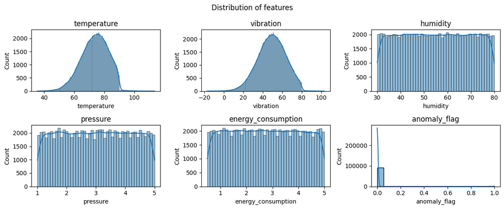

```python
features = ["temperature", "vibration", "humidity", "pressure", "energy_consumption", "anomaly_flag"]
fig, axes = plt.subplots(nrows=2, ncols=3, figsize=(12, 5))
axes = axes.flatten()

for ax, feat in zip(axes, features):
    sns.histplot(data[feat], kde=True, ax=ax)
    ax.set_title(f"{feat}")

plt.suptitle('Distribution of features')
plt.tight_layout()
```

Similarly, we plot the boxplot of the features

- As we can see in the temperature and vibration boxplot, they are the features that contains a lot of outliers, as compared to the others (humidity, pressure, and energy consumption)

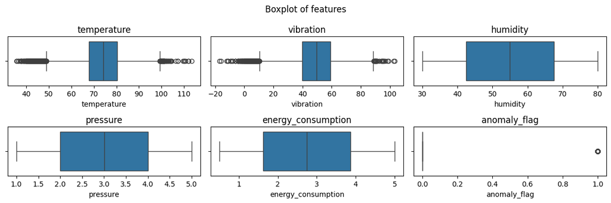

```python
fig, axes = plt.subplots(nrows=2, ncols=3, figsize=(12, 4))
axes = axes.flatten()

for ax, feat in zip(axes, features):
    sns.boxplot(x=data[feat], ax=ax)
    ax.set_title(f"{feat}")

plt.suptitle('Boxplot of features')
plt.tight_layout()
```

```
Labels: Counter({0: 1729, 1: 10})
```

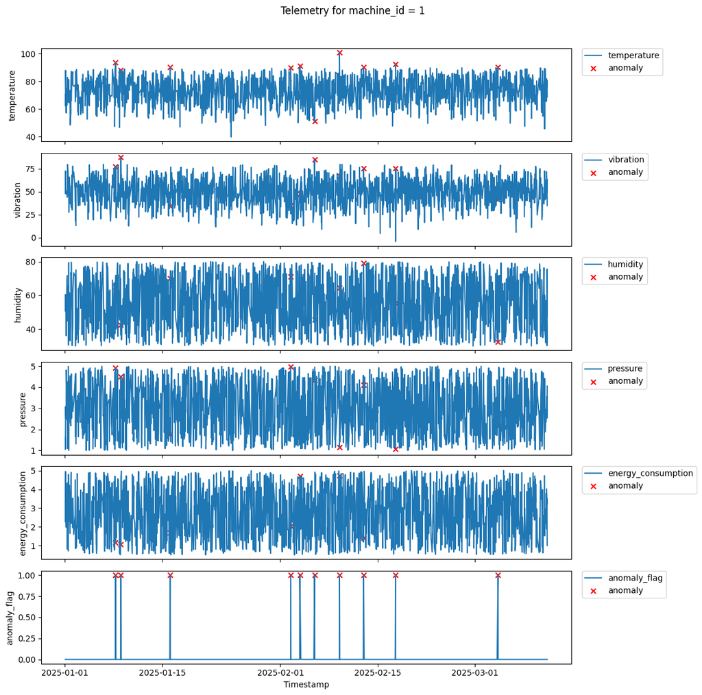

```python
# Choose a specific machine to visualize:
mid = data['machine_id'].unique()[0]
sub = data[data['machine_id'] == mid].sort_values('timestamp')
print('Labels:', Counter(sub["anomaly_flag"].tolist()))

fig, axes = plt.subplots(nrows=len(features), ncols=1, figsize=(12, 2*len(features)), sharex=True)
for ax, feat in zip(axes, features):
    ax.plot(sub['timestamp'], sub[feat], label=feat)
    ax.scatter(sub['timestamp'][sub['anomaly_flag']==1],
               sub[feat][sub['anomaly_flag']==1],
               color='red', marker='x', label='anomaly')
    # ax.legend(loc='upper right')
    ax.legend(loc='upper left', bbox_to_anchor=(1.02, 1), borderaxespad=0)
    ax.set_ylabel(feat)
axes[-1].set_xlabel('Timestamp')
plt.suptitle(f"Telemetry for machine_id = {mid}")
plt.tight_layout(rect=[0, 0, 1, 0.96])
```

Next, we can look at the correlation and interaction heatmap. From here, we can see that temperature and vibration is correlated to anomaly more than the other features, indicating that they will be the most significant features to indicates an anomaly.

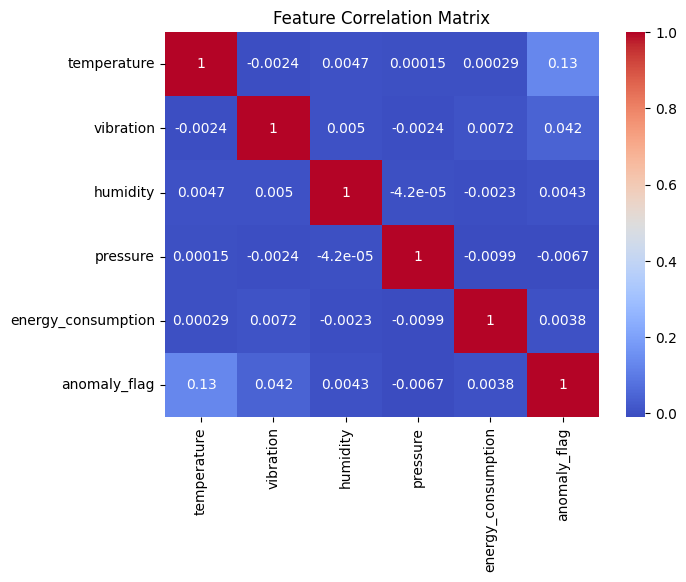

```python
plt.figure(figsize=(7,5))
sns.heatmap(data[features].corr(), annot=True, cmap="coolwarm")
plt.title("Feature Correlation Matrix")
plt.show()
```

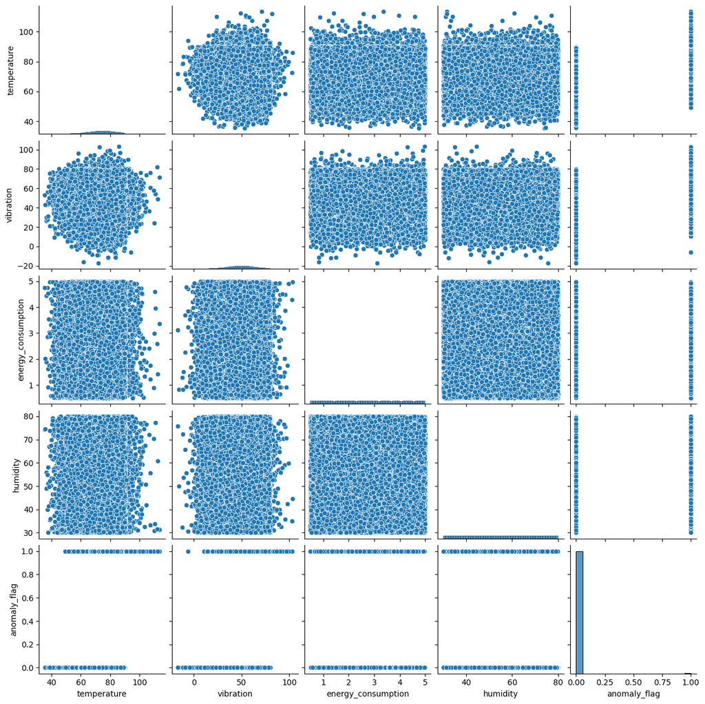

```python
sns.pairplot(data[["temperature","vibration","energy_consumption","humidity", 'anomaly_flag']])
plt.show()
```